# Confidence Intervals: Bayesian vs. Frequentist

```r
library(tidyverse)
```

# Random Variables

# Quantifying Confidence in a Sample Proportion

Does drug A or drug B work better?

Suppose that if we extract a random sick person from the general population and give them drug A, then the probability that that person would recover from their sickness is $\theta_A$. $\theta_A$ is the true proportion of sick people treated with drug A that recover.

If we were to extract a random sick person from the general population and give them drug B, then the probability that we’d see that person recover from their sickness is $\theta_B$. $\theta_B$ is the true proportion of sick people treated with drug B that recover.

Suppose that we don’t known the true value of $\theta_A$, nor the true value of $\theta_B$.

We do the following:

1. We give 100 random sick people drug A. We observe that 90 of them recover. This data gives us a point estimate $\hat\theta_A=0.9$ of $\theta_A$.
2. We give 100 random sick people drug B. 95 of them recover. This gives us a point estimate $\hat\theta_B=0.95$ of $\theta_B$.

How can we objectively quantify our uncertainty in these estimates $\hat\theta_A$ and $\hat\theta_B$, and in the difference between them?

# Bayesian Appraoch

For the Bayesian approach, we first must quantify our belief in different possible values of $\theta_A$ before observing any data. We do this using a **prior distribution**.

For example, suppose that we choose the following **prior distribution** for $\theta_A$:

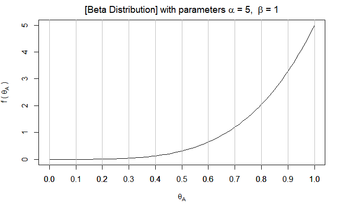

Notice that we believe that higher values of $\theta_A$ are much more likely than lower values.

The choice of a **beta** distribution for the **prior distribution** is for mathematical convenience (see https://en.wikipedia.org/wiki/Conjugate_prior for details).